# Final Project

Amanu Huq

12/15/2019

```r
# Metadata set
#ID: is the identification #
#bahtroom: number of full
#hf_broom:Number of Half Bathrooms (no bathtub or shower)
#heat:Heating amount in the property.
#ac: Cooling of the property, denoted by Y=yes or N=no,
#NUM_UNITS:Number of Units available in the neighborhood
#room:Number of Rooms in the propertp
#BEDRM:Number of Bedrooms in the property
#AYB:The earliest time the main portion of the building was built
#YR_RMDL:The year the  property was remodeled
#EYBL The year an improvement was built more recent than actual year built
#STORIES: Number of stories/ floors in primary dwelling
#SALEDATE:Date of most recent sale
#PRICE:Price of most recent sale
#QUALIFIED:Q=Qualified or U=unqualified to be sold as a property
#SALE_NUMSale Number
#GBAGross building area in square feet
#BLDG_NUMBuilding Number on Property
#STYLE:Style of the property
#STRUCT:Structure
#GRADE:Grade of the house quality
#CNDTN:Condition of property
#EXTWALL:Types of Extrerior wall
#ROOF:Roof types
#INTWALL: Material of PresInterior wall
#KITCHENS:Number of kitchens
#FIREPLACES:Number of fireplaces
#USECODE:Property use code
#LANDAREA:Land area of property in square feet
#GIS_LAST_MOD_DTTM:Last Modified Date
#SOURCE:Raw Data Source
#CMPLX_NUM:Complex number
#LIVING_GBA:Gross building area in square feet
#FULLADDRESS:Full Street Address
#CITY:City
#STATE:State
#ZIPCODE:Zip Code
#NATIONALGRIDAddress: location national grid coordinate spatial address
#LATITUDE:Latitude
#LONGITUDELLongitude
#ASSESSMENT_NBHD:Neighborhood ID
#ASSESSMENT_SUBNBHD:Subneighborhood ID
#CENSUS_TRACT:Census tract
#CENSUS_BLOCK:Census block
#WARDWard (District is divided into eight wards, each with approximately 75,000 residents)
#SQUARESquare (from SSL)
#Xlongitude
#Ylatitude
#QUADRANTCity: quadrant (NE,SE,SW,NW)
```

#2

```r
dcprop<-replace(dcprop, dcprop == "na", NA)

#1: Check for missing values:1356686
sum(is.na(dcprop))
```

```
## [1] 1356686
```

```r
#2: Check for percentage of missing values in the entire data set:17.4%
mean(is.na(dcprop)*100)
```

```
## [1] 17.41821
```

```r
#3:Change na to NA
dcprop<-replace(dcprop, dcprop == "na", NA)
```

```r
#Variation Questions
#Which grading category frequents the most in D.C. properties/residences?
#What is the pattern and disribution of the room count category  in D.C. properties.
```

#4

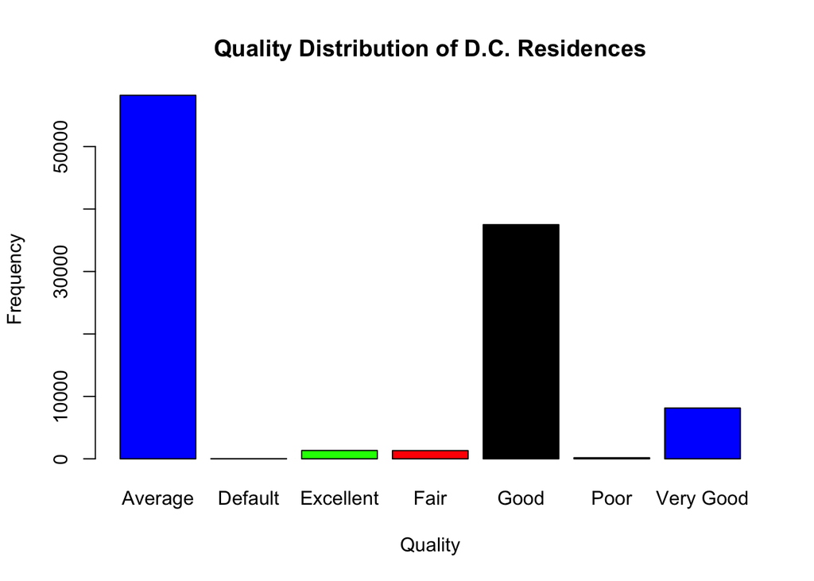

```r
gender_barplot<- barplot(table(dcprop$CNDTN), xlab="Quality", ylab="Frequency",col=c("blue","brown","green","red","black","yellow"),main="Quality Distribution of D.C. Residences")
```

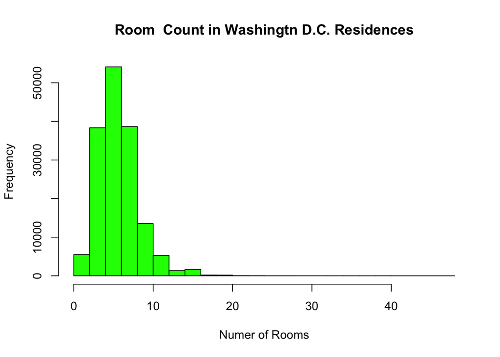

```r
hist(dcprop$rooms, col="green", xlab= "Numer of Rooms", ylab="Frequency", main=" Room  Count in Washingtn D.C. Residences ")
```

5: The data visualizations and general data can be used to make many inferences and solidify assumptions to concrete statements above. The data to begin with is about Washington D.C. residential properties. 49 variables are used to help sort and categorize the properties in D.C. Variables range from the number of bathrooms, rooms, stories in the house to the house quality assignment by contractors . I wanted to explore the size aspect of the homes, by seeing the patterns in the number of rooms. In addition, analyse which category of grading assignment is usually given to D.C. properties. I wanted to explore these two varibales, because often times there is a perception that residential properties in Washington D.C. are rundown and small in space available. While, this may be true for a certain portion of residences, expecially in urban cities. I want to explore if this is actually an assumption or a true reality according to this data.

It is important to take into account of missing values so when making visualization and other inferences of data ,one knows how much data they are working with. The sum of all missing data values is 1356686, which is only 17.4% of the whole data set. That is not a bad number considering the amount of numerical data in the data set. Also, all the data was regiestered as NA, but for a couple of “na”, which were converted to NA. Then the barchart of the quality distribution of D.C. residences cearly shows that “Average” category has the highest frequency, preceded by “Good” and then “Very Good”. Having “Average” as a benchmark is good when it comes ot housing quality in a mass scale , especially in urban cities. However, it is important to be aware of the fact that the requirement of what makes a property average is uknown to me for this data set. So for someone, who is actually using this in a real life setting should inquire about that. However, having “good”,and “very good” is a good sign, rather than poor and fair. This shows that most of the properties in Washington D.C. are average or above average. Another observation, I made is that “excellent” properties are basically close to zero. This could be because there is very a shortage of economic resouces and management required to elevate a “very good” propery to an “excellent” property.

#6

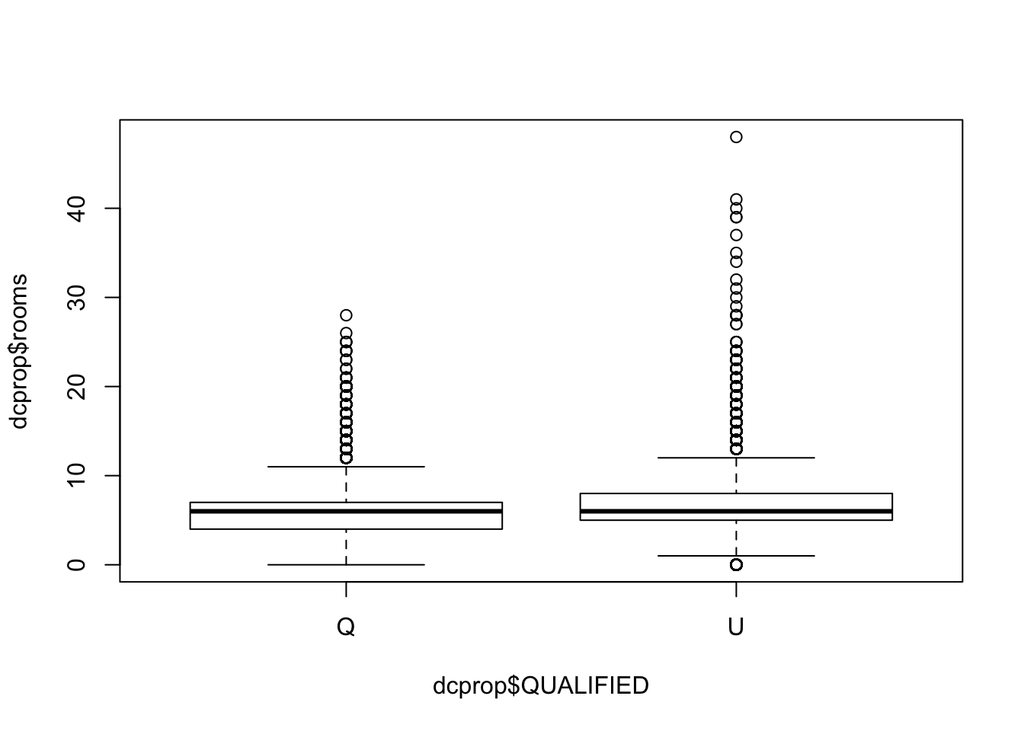

```r
#Question: Are the mean of of rooms for Qualified and Unqualified equal to one another?
boxplot(dcprop$rooms~dcprop$QUALIFIED)
```

```r
# The first assumtpion is that the sample must be random, which for my data set that is true because the properties used for this data set were chosen on a random lottery basis for this project. The random variable is normally distributed, and the random variable is reffered as assumption b.
#H0: mean rooms of Qualified properties = mean rooms of Unqualified properties
#HA:  mean rooms of Qualified properties != mean rooms of Unqualified properties
# mean two sided t-tests
t.test(dcprop$rooms~dcprop$QUALIFIED, mu=0, alt="two.sided", conf=0.95, var.eq=T, paired=F)
```

```
##
##  Two Sample t-test
##
## data:  dcprop$rooms by dcprop$QUALIFIED
## t = -36.262, df = 158955, p-value < 2.2e-16
## alternative hypothesis: true difference in means is not equal to 0
## 95 percent confidence interval:
##  -0.5003183 -0.4490064
## sample estimates:
## mean in group Q mean in group U
##        5.941060        6.415722
```

```r
#p-value < 2.2e-16
# Since, the p-value is less than 0.05, the null hypothesis is rejected
# There is enough evidence to show that the mean rooms of qualified prperties is not equal to the mean rooms of unqualified propertie
```

#7

```r
#Question: Is the numeber of rooms and bathrooms independent of one another?
table(dcprop$rooms,dcprop$bathroom)
```

```
##
##          0     1     2     3     4     5     6     7     8     9    10
##   0     35    78    17     2     4     1     1     0     0     0     0
##   1      6    89     0     1     0     0     0     0     0     0     0
##   2      1  5250    43     0     0     0     0     0     0     0     0
##   3      1 17304   444     9     1     0     0     0     0     0     0
##   4      3 11481  9007    84    17     1     0     0     0     0     0
##   5      4  8960  7013   847    27     1     0     0     0     0     0
##   6      3 18948 14420  3627   244    13     4     0     0     0     0
##   7      2  8013 10069  3829   392    27     4     2     0     0     0
##   8      2  3250  7166  4766  1028    92    20     3     0     0     0
##   9      1   812  2829  2930   870   141    26     5     1     0     0
##   10     0   274  1514  2649  1158   248    59     5     1     0     0
##   11     0    56   453   922   662   199    59    11     0     2     0
##   12     0    26   232   691  1627   246    78    21     7     1     0
```

[output cut: 69 more lines]

```r
# This data was randomly taken, whcih fulfills the first assumption. Secondly, the assumptions is the expected value is greater than 5.
# H0: # of rooms independent of # of bathrooms
# hA: # of rooms dependent of # of bathrooms
chisq.test(table(dcprop$rooms,dcprop$bathroom))
```

```
##
##  Pearson's Chi-squared test
##
## data:  table(dcprop$rooms, dcprop$bathroom)
## X-squared = 406766, df = 546, p-value < 2.2e-16
```

```r
# p-value < 2.2e-16
# Reject the null hypothesis, because H0<0.05
# There is enough evidence to conclude that the number of rooms and bathrooms are dependent of one another.
```

#8

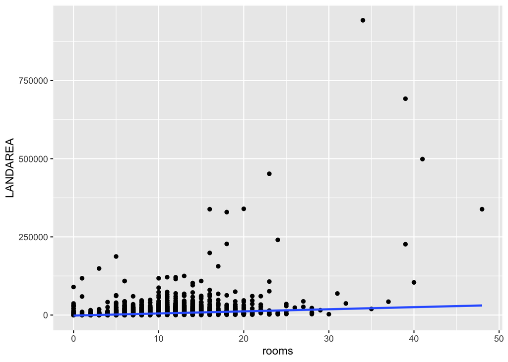

```r
#Question: Is the numeber of rooms and Landarea of properites related to one another?
ggplot(dcprop, aes(rooms, LANDAREA)) +
  geom_point() +
  geom_smooth(method = lm, se = FALSE)
```

```r
lin_model <- lm(dcprop$LANDAREA~ dcprop$rooms, na.rm=FALSE)
lin_model_land<-lm(dcprop$rooms~ dcprop$LANDAREA)
lin_model
```

```
##
## Call:
## lm(formula = dcprop$LANDAREA ~ dcprop$rooms, na.rm = FALSE)
##
## Coefficients:
##  (Intercept)  dcprop$rooms
##      -1689.8         672.8
```

```r
lin_model_land
```

```
##
## Call:
## lm(formula = dcprop$rooms ~ dcprop$LANDAREA)
##
## Coefficients:
##     (Intercept)  dcprop$LANDAREA
##       5.7420684        0.0001802
```

```r
# Rooms Coefficient: 672.8
# Rooms and Land area have a positive coeffieict, but there are so many outliers that the data points are sparse as it increases.
```

Then the chi-sqaured test was showing if the number of rooms and bathrooms are indpenedent of one another. Typically, the more the number of rooms, the more is the number of bathrooms. However, the chi-squared test would confirm or deny that. First, a contingency table was made to show this and then inserted into the chisquared test. Since, the p-value was less than 0.05 the null hypothesis is rejected, it can be concluded that the number of rooms and bathrooms are dependent on one another.